# Final Proyect

Andrea, Itzy, Marco, Reyli

2026-06-10

# Análisis de RNA-seq de la actividad de el bacteriofago T4 durante la infección de de *E.coli*

## Descripción de los datos

Los datos de RNA-seq analizados en este proyecto provienen del bioproyecto **PRJNA868713**, depositado en la base de datos GEO bajo la accesión **GSE211026**. El organismo de estudio es *Escherichia coli*, por lo que no aplica una clasificación por tejido o tipo celular. Este conjunto de datos fue generado por Wolfram-Schauerte et al. (2022) en el marco de un estudio Omics Reveal Time-Resolved Insights into T4 Phage Infection of E. coli on Proteome and Transcriptome Levels. La secuenciación se llevó a cabo mediante la plataforma Illumina NextSeq 500.

Para el diseño experimental se compraron bacterias de *E.coli* no infectadas vs. bascterias infectadas con bacteriofagos T4 a distintos tiempos post-infección. Se generaron 15 trancriptomas de los cuales se distribuyeron en las siguientes condiciones:

Control:

- Sin infección (3 réplicas biológicas)

Tratamiento:

- 1 minuto post-infección (3 réplicas biológicas)
- 4 minutos post-infección (3 réplicas biológicas)
- 7 minutos post-infección (3 réplicas biológicas)
- 20 minutos post-infección (3 réplicas biológicas)

El tipo de biblioteca empleada para el análisis fue single-end stranded preparadas con NEBNext Ultra II Directional RNA Library Prep Kit. El método de selección fue por medio de la depleción de ARN ribosomal con el Ribo-Zero rRNA Removal Kit

Table 1: Profundidad de secuenciación de cada transcriptoma

[output not shown]

## Resultados

### Calidad de las secuencias

Para el análisis de calidad de los 15 transcriptomas se usó la herramienta fastqc v. 0.11.3 y Multiqc v. 1.35 de los cuales obtuvimos los siguientes resultados

Table 2. Calidad de secuenciación de las lecturas

| Sample Name | Dups | GC | Seqs |
| --- | --- | --- | --- |
| SRR21013136_1 | 88.7% | 41.0% | 21.2M |
| SRR21013137_1 | 90.2% | 41.0% | 43.6M |
| SRR21013138_1 | 90.2% | 41.0% | 40.3M |
| SRR21013139_1 | 88.8% | 42.0% | 34.7M |
| SRR21013140_1 | 90.1% | 41.0% | 57.2M |
| SRR21013141_1 | 87.6% | 40.0% | 24.2M |
| SRR21013142_1 | 87.1% | 45.0% | 38.2M |
| SRR21013143_1 | 87.1% | 44.0% | 38.0M |
| SRR21013144_1 | 79.3% | 45.0% | 22.1M |
| SRR21013145_1 | 83.8% | 51.0% | 31.9M |
| SRR21013146_1 | 84.9% | 52.0% | 43.0M |
| SRR21013147_1 | 86.2% | 52.0% | 60.1M |
| SRR21013148_1 | 81.2% | 52.0% | 21.4M |
| SRR21013149_1 | 85.3% | 52.0% | 48.5M |
| SRR21013150_1 | 85.3% | 52.0% | 42.6M |

Además se observó que aún se conservaban los adaptadores para cada uno de los 15 transcriptomas

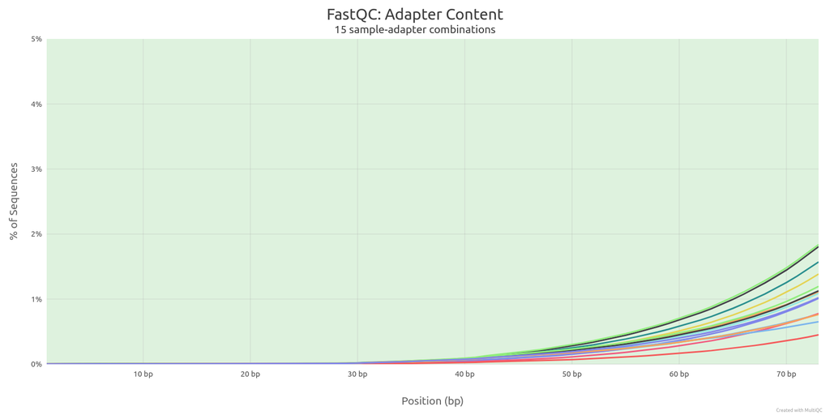

La limpieza de los datos se realizó con `cutadapt` (v5.2) para eliminar las secuencias del adaptador Illumina TruSeq (GATCGGAAGAGCACACGTCTGAACTCCAGTCAC) introducidas en el extremo 3’ (`-a`). Durante este proceso, se implementó un filtrado por calidad (`-q 20`) y un recorte por longitud mínima (`-m 35`), asegurando transcriptomas limpios y libres de contaminación técnica. Como resultado directo de este control de calidad, se observó una reducción controlada en el tamaño promedio de las secuencias remanentes.

Table 3. Calidad de secuenciación de las lecturas después de remover los adaptadores

| Sample Name | Dups | GC | Seqs |
| --- | --- | --- | --- |
| SRR21013136 | 87.5% | 40.0% | 19.5M |
| SRR21013137 | 88.8% | 41.0% | 40.5M |
| SRR21013138 | 89.1% | 40.0% | 39.1M |
| SRR21013139 | 87.4% | 41.0% | 32.0M |
| SRR21013140 | 89.1% | 40.0% | 54.3M |
| SRR21013141 | 87.0% | 40.0% | 24.2M |
| SRR21013142 | 85.4% | 44.0% | 35.4M |
| SRR21013143 | 85.7% | 43.0% | 36.0M |
| SRR21013144 | 79.0% | 45.0% | 22.1M |
| SRR21013145 | 82.2% | 52.0% | 29.9M |
| SRR21013146 | 83.9% | 52.0% | 40.5M |
| SRR21013147 | 85.4% | 52.0% | 58.8M |
| SRR21013148 | 79.2% | 52.0% | 20.0M |
| SRR21013149 | 84.3% | 52.0% | 46.6M |
| SRR21013150 | 84.5% | 52.0% | 42.0M |

### Alineamiento

El alineamiento de las lecturas se realizó mediante el software `HISAT2` (v2.2.1) bajo la modalidad de lecturas únicas (*Single-End*). Como estrategia bioinformática para evitar sesgos de mapeo cruzado, se concatenaron previamente las secuencias genómicas de *Escherichia coli* y el bacteriófago T4 en un archivo FASTA híbrido, sobre el cual se construyeron los índices genómicos utilizando el comando `hisat2-build`. Posteriormente, cada archivo de lecturas limpias fue procesado con `HISAT2`, empleando el parámetro por defecto para el reporte de alineamientos válidos y redirigiendo la salida estándar. Mediante el uso de `samtools` (v1.20), los archivos de texto SAM resultantes se convirtieron a formato binario compacto BAM (`samtools view -bS`), se ordenaron por coordenadas genómicas (`samtools sort`) y se indexaron (`samtools index`) para generar los archivos `.bai`. Este flujo permitió estructurar los datos de manera óptima para la posterior cuantificación de la expresión génica. La Table 4 muestra los porcentajes de alineamiento global obtenidos frente al genoma concatenado:

Table 4. Porcentaje de lecturas alineadas

| Sample Name | Porcentaje de lecturas alineadas |
| --- | --- |
| SRR21013136 | 97.64% |
| SRR21013137 | 97.60% |
| SRR21013138 | 97.47% |
| SRR21013139 | 96.96% |
| SRR21013140 | 97.07% |
| SRR21013141 | 97.16% |
| SRR21013142 | 96.36% |
| SRR21013143 | 96.46% |
| SRR21013144 | 95.35% |
| SRR21013145 | 95.28% |
| SRR21013146 | 94.92% |
| SRR21013147 | 95.28% |
| SRR21013148 | 95.00% |
| SRR21013149 | 95.05% |
| SRR21013150 | 95.34% |

### Predicción de cuentas

La cuantificación de los niveles de expresión génica se llevó a cabo utilizando la herramienta `featureCounts` integrada en el paquete `Subread` (v1.6.2). Los archivos de alineamiento en formato `.bam` se contrastaron contra el archivo de anotación GFF híbrido (correspondiente al genoma concatenado), empleando el parámetro `-t gene` para definir la característica genómica a cuantificar y `-g gene_id` para colapsar las lecturas a nivel de identificador de gen. Al tratarse de una biblioteca de lecturas únicas (*Single-End*), el conteo se realizó considerando asignaciones a nivel de lectura individual. Este procedimiento permitió estructurar de manera robusta la matriz de conteos crudos con la abundancia transcripcional de cada gen para el hospedero y el fago simultáneamente

### Expresión diferencial

Para descartar un posible efecto de lote se corrió una análisis de componentes principales. Como puedes observar, los puntos del mismo color se agrupan muy cerca entre sí (especialmente en los tiempos de 1, 7 y 20 minutos). Esto indica una excelente consistencia experimental: el ruido técnico es mínimo y las diferencias que estás observando se deben genuinamente a la progresión del tiempo de infección del fago T4 sobre *E. coli*.

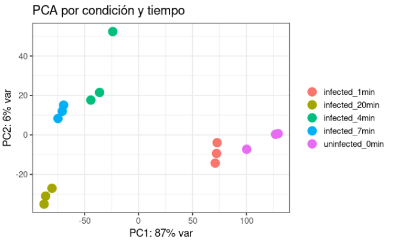

### Umap

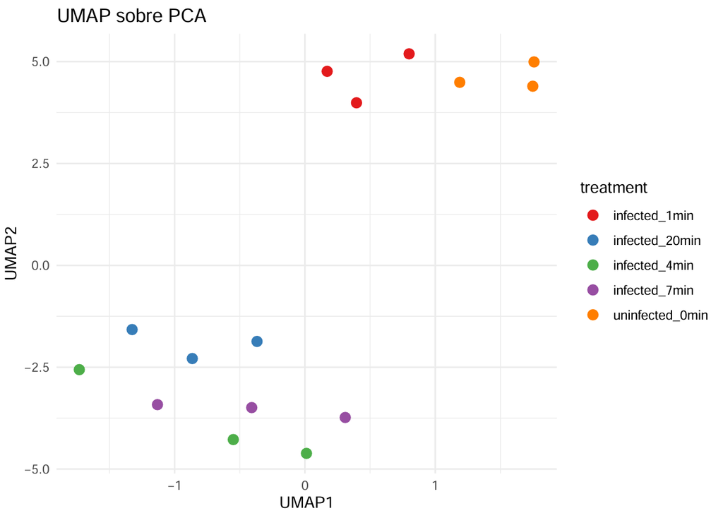

### Heatmaps y Volcano Plots

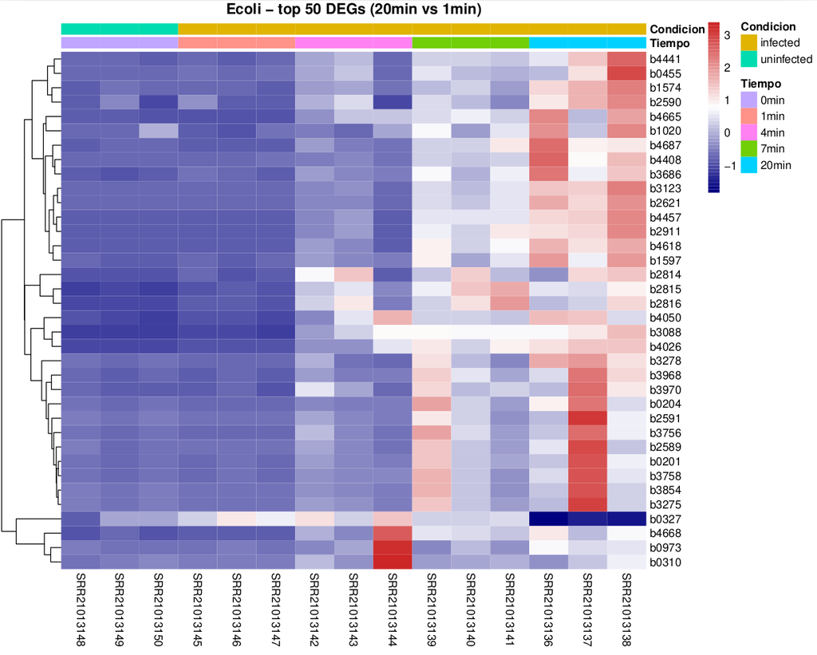

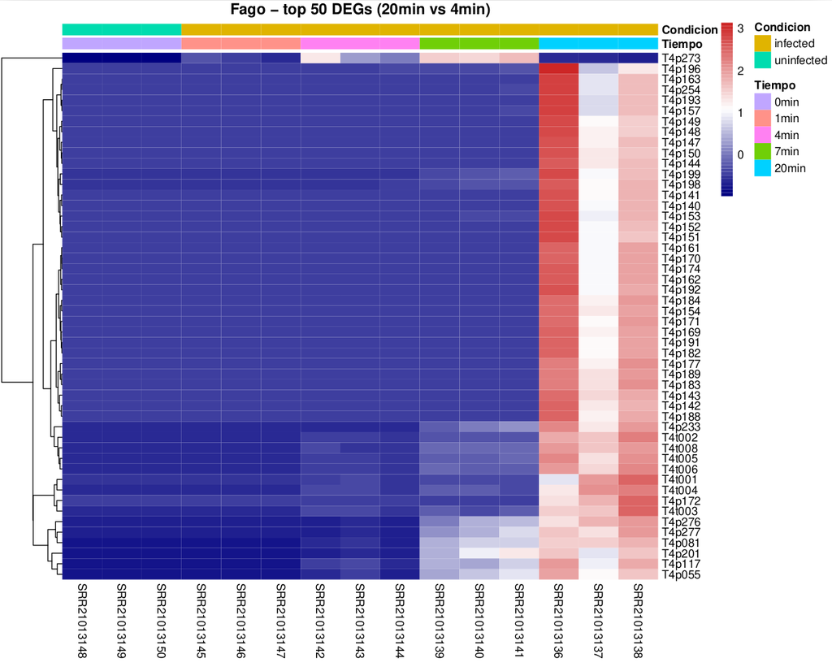

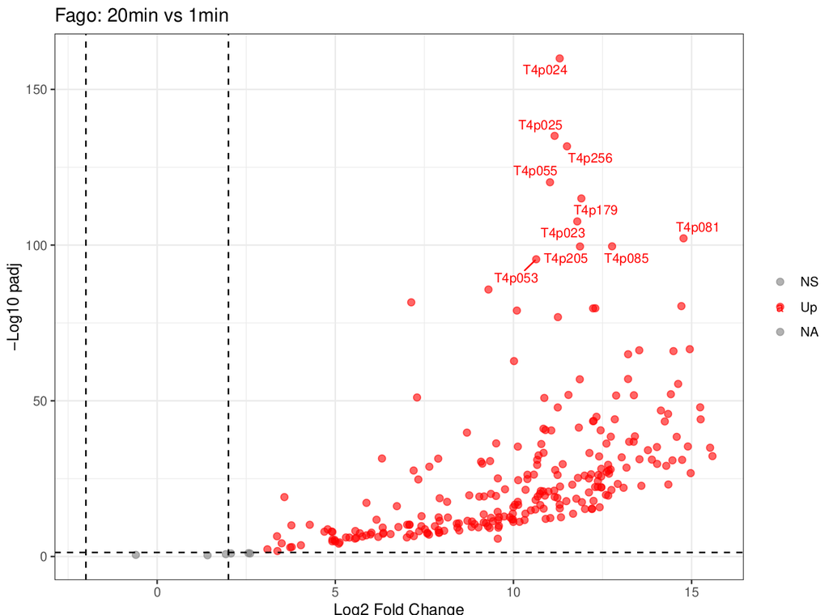

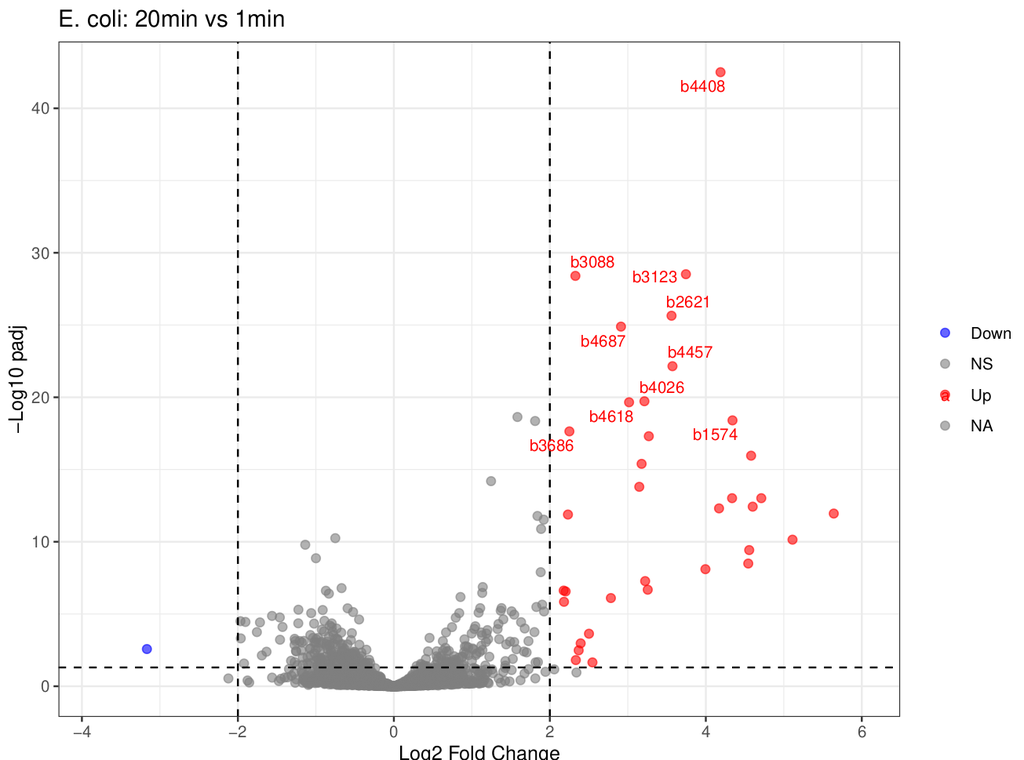

### Análisis de Enriquecimiento

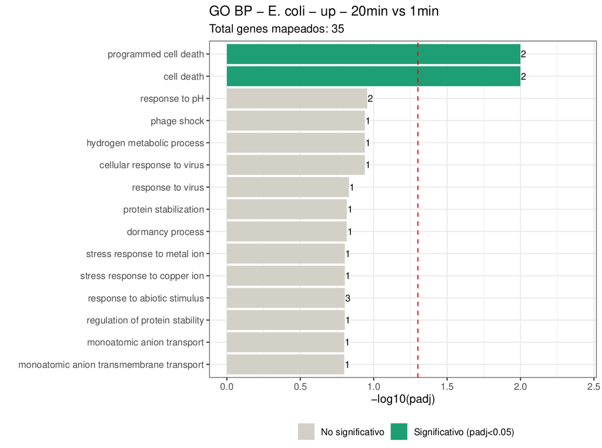

En el análisis de enrequecimiento en el minuto 20, podemos observar que el fago ya ha sintetizado cientos de copias de su propio genoma y ha ensamblado las cápsides virales. Para liberar los nuevos viriones al exterior, el fago activa proteínas específicas (holinas y lisozimas) que desestabilizan la membrana interna y degradan el peptidoglicano de la pared celular. La detección significativa de programmed cell death y cell death refleja que la maquinaria de *E. coli* está experimentando los eventos bioquímicos previos a la lisis celular.

## Discusión

Hacia el minuto 20, el encendido exclusivo de los genes tardíos del fago —controlado por el factor sigma secundario gp55 y sus coactivadores— marca el clímax del empaquetamiento de ADN y el autoensamblaje de la cápside. Curiosamente, Wolfram-Schauerte et al. (2022) demostraron que mientras el transcriptoma de *E. coli* es destruido casi en su totalidad, su proteoma permanece sorprendentemente estable debido a que T4 preserva intacta la maquinaria traduccional del hospedero para sostener la síntesis de sus propias proteínas estructurales. De este modo, el remanente de activación bacteriana detectado en el Volcano Plot (liderado por genes como `b4408`) y la significancia única de los términos GO de muerte celular reflejan el colapso y la respuesta terminal de estrés físico ante la acumulación de holinas virales justo antes de la lisis irreversible.

## Referencias

Chevallereau, A.; Pons, B.J.; van Houte, S.; Westra, E.R. Interactions between bacterial and phage communities in natural environments. Nat. Rev. Microbiol. 2022, 20, 49–62.

Rao, Venigalla, y Elizabeth Kutter. 2025. “The World of Bacteriophage T4: Seven Decades of Discovery.” *EcoSal Plus* 11 (1): esp-0006-2025.

Ueno, H.; Yonesaki, T. Phage-induced change in the stability of mRNAs. Virology 2004, 329, 134–141.

Wolfram-Schauerte, Maik, Nadiia Pozhydaieva, Madita Viering, Timo Glatter, and Katharina Höfer. 2022. “Integrated Omics Reveal Time-Resolved Insights into T4 Phage Infection of *E. coli* on Proteome and Transcriptome Levels” *Viruses* 14, no. 11: 2502